# Virat Kohli Centuries Analysis

### As a part of player perfomance Analysis, An Indian Ex-Captain and current player Virat Kohli Data as taken for Analysis

#### Virat Kohli is a professional cricketer from India who is widely regarded as one of the best batsmen of his generation. He has played in all three formats of the game - Test, One Day International (ODI), and Twenty20 International (T20I) - and has achieved remarkable success in each of them.

#### In Test cricket, Kohli has scored 8,676 runs in 111 matches (187 innings) at an average of 49.29. He has scored 29 centuries and 29 half-centuries in this format, with a highest score of 254*. Kohli has been particularly impressive in overseas conditions, where he has scored 4,532 runs at an average of 51.17.

#### In ODIs, Kohli has scored 13,848 runs in 292 matches (280 innings) at an average of 58.67. He has scored 50 100's & 72 half-centuries in this format, with a highest score of 183. Kohli holds the record for the fastest player to reach 10,000 runs in ODI cricket, achieving the feat in just 205 innings.

#### In T20Is, Kohli has scored 4,008 runs in 90 matches at an avg of 52.7, He has scored 1 century and 37 half centuries in this format, with a highest score of 122*.¶

```python
import pandas as pd
import numpy as np
import matplotlib.pyplot as plt
%matplotlib inline
```

```python
import io
%cd "C:\Users\gouth\OneDrive\Desktop\LMS Projects"
```

```
C:\Users\gouth\OneDrive\Desktop\LMS Projects
```

```python
viratkohli_df=pd.read_csv("Virat Kohli Centuries.csv")
```

```python
viratkohli_df.shape
```

```
(80, 18)
```

```python
viratkohli_df.info()
```

```
<class 'pandas.core.frame.DataFrame'>
RangeIndex: 80 entries, 0 to 79
Data columns (total 18 columns):
 #   Column        Non-Null Count  Dtype
---  ------        --------------  -----
 0   Number        80 non-null     int64
 1   Format        80 non-null     object
 2   Inning        80 non-null     int64
 3   Position      80 non-null     object
 4   Score         80 non-null     int64
 5   Balls         80 non-null     int64
 6   Strike Rate   80 non-null     float64
 7   Against       80 non-null     object
 8   Venue         80 non-null     object
 9   Host Nation   80 non-null     object
 10  Series        80 non-null     object
 11  Year          80 non-null     int64
 12  Team Total    80 non-null     int64
 13  Wickets lost  80 non-null     int64
 14  Not Out       80 non-null     object
 15  MOTM          80 non-null     object
 16  Win           80 non-null     object
 17  Captain       80 non-null     object
dtypes: float64(1), int64(7), object(10)
memory usage: 11.4+ KB
```

```python
viratkohli_df.head()
```

|  | Number | Format | Inning | Position | Score | Balls | Strike Rate | Against | Venue | Host Nation | Series | Year | Team Total | Wickets lost | Not Out | MOTM | Win | Captain |
| --- | --- | --- | --- | --- | --- | --- | --- | --- | --- | --- | --- | --- | --- | --- | --- | --- | --- | --- |
| 0 | 1 | ODI | 2 | 4 | 107 | 114 | 93.859649 | Sri Lanka | Kolkata | India | Bilateral | 2009 | 316 | 3 | No | No | Yes | No |
| 1 | 2 | ODI | 2 | 3 | 102 | 95 | 107.368421 | Bangladesh | Mirpur | Bangladesh | Tri-Series | 2010 | 249 | 4 | Yes | Yes | Yes | No |
| 2 | 3 | ODI | 2 | 3 | 118 | 121 | 97.520661 | Australia | Vizag | India | Bilateral | 2010 | 292 | 5 | No | Yes | Yes | No |
| 3 | 4 | ODI | 1 | 3 | 105 | 104 | 100.961539 | New Zealand | Guwahati | India | Bilateral | 2010 | 276 | 10 | No | Yes | Yes | No |
| 4 | 5 | ODI | 1 | 4 | 100 | 83 | 120.481928 | Bangladesh | Mirpur | Bangladesh | World Cup | 2011 | 370 | 4 | Yes | No | Yes | No |

```python
viratkohli_df.tail()
```

|  | Number | Format | Inning | Position | Score | Balls | Strike Rate | Against | Venue | Host Nation | Series | Year | Team Total | Wickets lost | Not Out | MOTM | Win | Captain |
| --- | --- | --- | --- | --- | --- | --- | --- | --- | --- | --- | --- | --- | --- | --- | --- | --- | --- | --- |
| 75 | 76 | Test | 1 | 4 | 121 | 206 | 58.737864 | West Indies | Port Of Spain | West Indies | Bilateral | 2023 | 438 | 10 | No | No | Drawn | No |
| 76 | 77 | ODI | 1 | 3 | 122 | 94 | 129.787234 | Pakistan | Colombo | Sri Lanka | Asia Cup | 2023 | 356 | 2 | Yes | Yes | Yes | No |
| 77 | 78 | ODI | 2 | 3 | 103 | 97 | 106.185567 | Bangladesh | Pune | India | World Cup | 2023 | 261 | 3 | Yes | Yes | Yes | No |
| 78 | 79 | ODI | 1 | 3 | 101 | 121 | 83.471074 | South Africa | Kolkata | India | World Cup | 2023 | 326 | 5 | Yes | Yes | Yes | No |
| 79 | 80 | ODI | 1 | 3 | 117 | 113 | 103.539823 | New Zealand | Mumbai | India | World Cup | 2023 | 397 | 4 | No | No | Yes | No |

```python
viratkohli_df.columns
```

```
Index(['Number', 'Format', 'Inning', 'Position', 'Score', 'Balls',
       'Strike Rate', 'Against', 'Venue', 'Host Nation', 'Series', 'Year',
       'Team Total', 'Wickets lost', 'Not Out', 'MOTM', 'Win', 'Captain'],
      dtype='object')
```

## Exploratory Data Analysis

```python
viratkohli=viratkohli_df.groupby('Year')
```

```python
print(viratkohli.count()['Number'])
```

```
Year
2009     1
2010     3
2011     4
2012     8
2013     6
2014     8
2015     4
2016     7
2017    11
2018    11
2019     7
2022     2
2023     8
Name: Number, dtype: int64
```

```python
year_centuries=np.array(viratkohli.count()['Number'])
```

```python
year=np.array(['2009','2010','2011','2012','2013','2014','2015','2016','2017','2018','2019','2022','2023'])
```

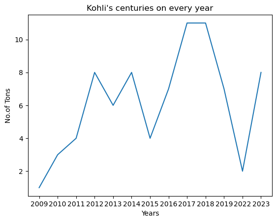

```python
plt.plot(year,year_centuries)
plt.xlabel('Years')
plt.ylabel('No.of Tons')
plt.title("Kohli's centuries on every year")
plt.show()
```

```python
import plotly.express as px
```

## Virat Kohli Centuries in Each Venue

```python
viratkohli_venue=viratkohli_df.groupby('Venue')
```

```python
print(viratkohli_venue.count()['Number'].head())
```

```
Venue
Adelaide      5
Ahmedabad     1
Bengaluru     1
Birmingham    1
Canberra      1
Name: Number, dtype: int64
```

```python
fig=px.pie(viratkohli_df,values='Number',names='Venue',hover_data=['Venue'],title="Virat Kohli centuries in each venue")
fig.update_traces(textposition='inside')
fig.show()
```

[interactive chart not shown]

## Virat Kohli Centuries across Formats

#### Formats - Test, ODI and T20I

```python
viratkohli_format=viratkohli_df.groupby('Format')
```

```python
print(viratkohli_format.count()['Number'])
```

```
Format
ODI     50
T20i     1
Test    29
Name: Number, dtype: int64
```

```python
fig=px.pie(viratkohli_df,values='Number',names='Format',hover_data=['Format'],title="Virat Kohli centuries across format")
fig.show()
```

[interactive chart not shown]

```python
viratkohli_opponent=viratkohli_df.groupby('Against')
```

```python
viratkohli_opp=viratkohli_opponent.count()['Number']
```

```python
viratkohli=pd.DataFrame(viratkohli_opp)
```

```python
viratkohli
```

| Against | Number |
| --- | --- |
| Afghanistan | 1 |
| Australia | 16 |
| Bangladesh | 7 |
| England | 8 |
| New Zealand | 9 |
| Pakistan | 3 |
| South Africa | 8 |
| Sri Lanka | 15 |
| West Indies | 12 |
| Zimbabwe | 1 |

## Virat Kohli centuries against an opposition in Test Format

```python
viratkohli_df[(viratkohli_df.Format=='Test')].groupby('Against').count()['Number'].sort_values(ascending=False)
```

```
Against
Australia       8
England         5
Sri Lanka       5
New Zealand     3
South Africa    3
West Indies     3
Bangladesh      2
Name: Number, dtype: int64
```

## Virat Kohli centuries against an opposition in ODI Format

```python
viratkohli_df[(viratkohli_df.Format=='ODI')].groupby('Against').count()['Number'].sort_values(ascending=False)
```

```
Against
Sri Lanka       10
West Indies      9
Australia        8
New Zealand      6
Bangladesh       5
South Africa     5
England          3
Pakistan         3
Zimbabwe         1
Name: Number, dtype: int64
```

## Virat Kohli centuries against an opposition in T20I Format

```python
viratkohli_df[(viratkohli_df.Format=='T20i')].groupby('Against').count()['Number'].sort_values(ascending=False)
```

```
Against
Afghanistan    1
Name: Number, dtype: int64
```

## No. of Centuries as Captain and as Player

```python
viratkohli_captain=viratkohli_df.groupby('Captain')
```

```python
captain=viratkohli_captain.count()['Number']
```

```python
print(captain)
```

```
Captain
No     39
Yes    41
Name: Number, dtype: int64
```

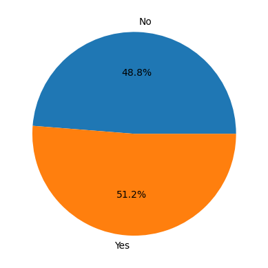

```python
plt.pie(captain,labels=['No','Yes'],autopct='%1.1f%%')
plt.show()
```

#### Virat Kohli scored 41 Centuries as Captain across formats and 39 Centuries as player

## Instance of winning Man of the match after scoring a Century

```python
viratkohli_motm=viratkohli_df.groupby('MOTM').count()['Number']
```

```python
print(viratkohli_motm)
```

```
MOTM
No     34
Yes    46
Name: Number, dtype: int64
```

[figure not shown]

```python
plt.pie(captain,labels=['No','Yes'],autopct='%0.0f%%')
plt.show()
```

#### Virat Kohli won 46 Man of the match across formats when scored a Century

## Centuries Scored at different batting positions by Virat Kohli

```python
viratkohli_pos=viratkohli_df.groupby('Position')
```

```python
pos=viratkohli_pos.count()
print(pos['Number'])
```

```
Position
3       43
4       32
5        3
6        1
Open     1
Name: Number, dtype: int64
```

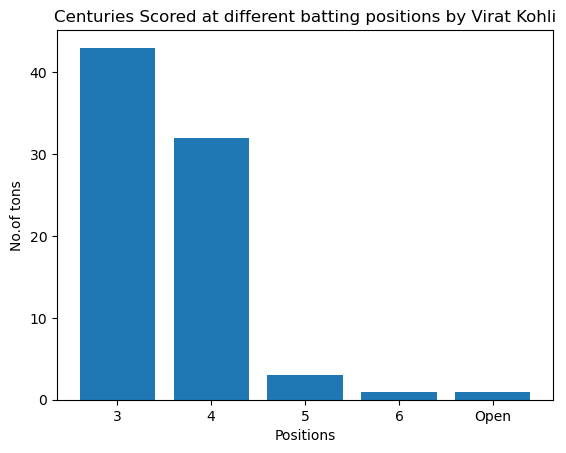

```python
plt.bar(['3','4','5','6','Open'],height=pos['Number'])
plt.xlabel('Positions')
plt.ylabel('No.of tons')
plt.title('Centuries Scored at different batting positions by Virat Kohli')
plt.show()
```

#### Virat Kohli has scored 75 Centuries across formats in 3rd and 4th batting position

## No. of Centuries by Virat Kohli in Different Innings of an ODI

```python
odi_first=viratkohli_df[(viratkohli_df.Format=='ODI')&(viratkohli_df.Inning==1)].count()['Number']
odi_second=viratkohli_df[(viratkohli_df.Format=='ODI')&(viratkohli_df.Inning==2)].count()['Number']
```

```python
kohli_ODIinnings=pd.DataFrame({'Innings':['First Innings','Second Innings'],'Tons':[odi_first,odi_second]},index=(1,2))
```

```python
kohli_ODIinnings
```

|  | Innings | Tons |
| --- | --- | --- |
| 1 | First Innings | 23 |
| 2 | Second Innings | 27 |

```python
fig=px.pie(kohli_ODIinnings,values='Tons',names='Innings',
           title="No. of Centuries by Virat Kohli in Different Innings of an ODI")
fig.show()
```

[interactive chart not shown]

#### Virat Kohli has 23 Centuries in First innings and 27 Centuries in Second innings of an One Day International Match

#### No wonder why he is called as CHASE MASTER

## No. of Centuries by Virat Kohli in Different Innings of a Test match

```python
test_first=viratkohli_df[(viratkohli_df.Format=='Test')&(viratkohli_df.Inning==1)].count()['Number']
test_second=viratkohli_df[(viratkohli_df.Format=='Test')&(viratkohli_df.Inning==2)].count()['Number']
test_third=viratkohli_df[(viratkohli_df.Format=='Test')&(viratkohli_df.Inning==3)].count()['Number']
test_fourth=viratkohli_df[(viratkohli_df.Format=='Test')&(viratkohli_df.Inning==4)].count()['Number']
```

```python
kohli_TESTinnings=pd.DataFrame({'Innings':['First Innings','Second Innings','Third Innings','Fourth Innings'],
                                'Tons':[test_first,test_second,test_third,test_fourth]},index=(1,2,3,4))
```

```python
kohli_TESTinnings
```

|  | Innings | Tons |
| --- | --- | --- |
| 1 | First Innings | 9 |
| 2 | Second Innings | 15 |
| 3 | Third Innings | 3 |
| 4 | Fourth Innings | 2 |

```python
fig=px.pie(kohli_TESTinnings,values='Tons',names='Innings',
           title="No. of Centuries by Virat Kohli in Different Innings of a Test match")
fig.show()
```

[interactive chart not shown]

## No. of Centuries by Virat Kohli in Different Innings of a T20i

```python
T20i_first=viratkohli_df[(viratkohli_df.Format=='T20i')&(viratkohli_df.Inning==1)].count()['Number']
T20i_second=viratkohli_df[(viratkohli_df.Format=='T20i')&(viratkohli_df.Inning==2)].count()['Number']
```

```python
kohli_T20iinnings=pd.DataFrame({'Innings':['First Innings','Second Innings'],'Tons':[T20i_first,T20i_second]},index=(1,2))
```

```python
kohli_T20iinnings
```

|  | Innings | Tons |
| --- | --- | --- |
| 1 | First Innings | 1 |
| 2 | Second Innings | 0 |

```python
fig=px.pie(kohli_T20iinnings,values='Tons',names='Innings',
           title="No. of Centuries by Virat Kohli in Different Innings of a T20i")
fig.show()
```

[interactive chart not shown]

## No. of Centuries in Different Host Nations

```python
viratkohli_nation=pd.DataFrame(viratkohli_df.groupby('Host Nation').count()['Number'])
```

```python
viratkohli_nation
```

| Host Nation | Number |
| --- | --- |
| Australia | 11 |
| Bangladesh | 6 |
| England | 3 |
| India | 36 |
| New Zealand | 4 |
| South Africa | 5 |
| Sri Lanka | 7 |
| UAE | 1 |
| West Indies | 6 |
| Zimbabwe | 1 |

#### VK has scored 11 Centuries in Australia, His best among host nations other than Home Country (India)

```python
host_nations=['AUS','BAN','ENG','IND','NZ','SA','SL','UAE','WI','ZIM']
```

```python
colors=['y','g','skyblue','deepskyblue','k','forestgreen','dodgerblue','darkslategray','maroon','orangered']
```

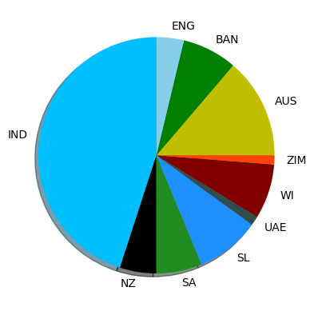

```python
plt.pie(viratkohli_nation['Number'],
        labels=host_nations,colors=colors,shadow=True)
plt.show()
```

## Centuries in Different Series

```python
viratkohli_series=viratkohli_df.groupby('Series').count()['Number']
```

```python
viratkohli_series
```

```
Series
Asia Cup       5
Bilateral     67
Tri-Series     3
World Cup      5
Name: Number, dtype: int64
```

#### Virat Kohli is also a Big match player. He has scored 5 Centuries in Asia cup and 5 in ICC cricket world Cup

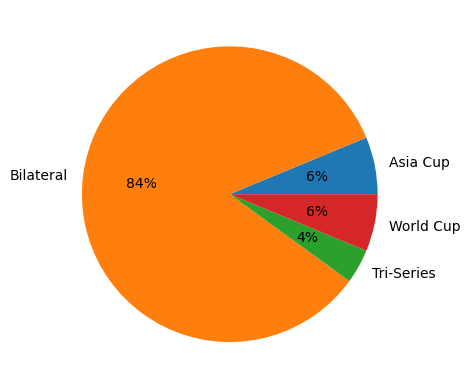

```python
plt.pie(viratkohli_series,labels=viratkohli_series.index,autopct='%0.0f%%')
plt.show()
```

## VK's Contribution for Team total at each Instance

```python
kohli_contribution=pd.DataFrame(viratkohli_df['Score']/viratkohli_df['Team Total']*100)
```

```python
kohli_contribution.columns=['Percentage']
```

```python
print(kohli_contribution)
print('Average Percentage')
np.mean(kohli_contribution)
```

```
    Percentage
0    33.860759
1    40.963855
2    40.410959
3    38.043478
4    27.027027
..         ...
75   27.625571
76   34.269663
77   39.463602
78   30.981595
79   29.471033

[80 rows x 1 columns]
Average Percentage
```

```
Percentage    39.458922
dtype: float64
```

### Sorting the values according to the percentage

```python
kohli_percentage=kohli_contribution.sort_values(by='Percentage',ascending=False)
kohli_percentage
```

|  | Percentage |
| --- | --- |
| 23 | 63.253012 |
| 55 | 62.621359 |
| 70 | 57.547170 |
| 11 | 55.454545 |
| 56 | 54.379562 |
| ... | ... |
| 32 | 27.466667 |
| 4 | 27.027027 |
| 27 | 25.900901 |
| 58 | 21.417565 |
| 16 | 18.706294 |

80 rows × 1 columns

```python
virat_contribution=kohli_contribution[(kohli_contribution.Percentage>=50)].count()
```

```python
print('No.of Times when kohli scored a ton which contributed the majority of runs to the team total,',
      virat_contribution)
```

```
No.of Times when kohli scored a ton which contributed the majority of runs to the team total, Percentage    10
dtype: int64
```

##### Overall, Kohli's performance in international cricket has been nothing short of outstanding. He is a technically sound batsman with a wide range of strokes and excellent temperament. Kohli is also an excellent captain, having led India to numerous victories in all three formats of the game. His contribution to Indian cricket has been immense, and he is widely regarded as one of the greatest cricketers to have ever played the game.

##### Virat Kohli's performance in cricket can be described as exceptional, both in terms of his individual statistics and his contribution to the success of the Indian cricket team.

##### Kohli is widely regarded as one of the best batsmen of his generation and his record in all three formats of the game speaks for itself. He has scored a remarkable number of runs, with an average that is consistently above 50 in all formats of the game. His ability to score runs under pressure and in tough conditions is particularly impressive, and he has produced some memorable innings in important matches.

##### Apart from his batting, Kohli is also an excellent fielder and a tactically astute captain. He is known for his aggressive and proactive approach to captaincy, and has led India to numerous victories in all three formats of the game.

##### Overall, Kohli's performance in cricket has been outstanding, and he has established himself as one of the greatest cricketers of all time. His talent, hard work, and dedication have earned him a place among the cricketing elite, and he is widely respected both within India and around the world.